# selma: smooth relative SELectivity curves using weighted polynomial basis via Model Averaging

October, 2025

### Initials

The following packages are required to run the analysis:

```r
library(data.table)
library(ggplot2)
library(MuMIn)
library(doParallel)
library(foreach)
```

source the selma functions that are required to replicate the (catch comparison) analysis in Milanelli et al

load plaice **PLE** example data,

```r
PLE<-fread("./data/PLE.csv")
```

The data structure in `PLE` is

```r
str(PLE)
```

```
## Classes 'data.table' and 'data.frame':   911 obs. of  7 variables:
##  $ haul  : int  1 1 1 1 1 1 1 1 1 1 ...
##  $ string: chr  "A" "A" "A" "A" ...
##  $ l     : int  26 28 30 31 33 34 35 27 28 30 ...
##  $ n_1   : int  1 0 1 0 1 0 1 0 1 0 ...
##  $ n_2   : int  0 1 1 1 2 1 0 1 0 1 ...
##  $ q_1   : int  1 1 1 1 1 1 1 1 1 1 ...
##  $ q_2   : int  1 1 1 1 1 1 1 1 1 1 ...
##  - attr(*, ".internal.selfref")=<externalptr>
```

where + **haul** = Primary Sampling Unit (in the manuscript referred to as deployment) + **string** = Second Sampling Unit nested within haul + **n_1** = counts of measured fish at length `l` in the Pearlnet + **l** = length classes observed in catches + **n_1** = counts of measured fish at length `l` in the Pearlnet + **n_2** = counts of measured fish at length `l` in the standard net + **q_1** and **q_2** = raising factors for `n_1` and `n_2`, respectively

The function with model-averaging and bootstrap capabilities is named `selma_boot()` and can be called from the workspace. It requires the following arguments:

- **DT_in** = input catch data. Here `PLE`
- **lengthRange** = minimum and maximum lengths in the data set to be used in the analysis, normally lengthRange= the range in the data.
- **typePredict** = which type of prediction should the model provide. Use `response` as default.
- **ranking**= criteria for model averaging, use `AICc` as default.
- **sampler**= resampling scheme used for the bootstrap distribution generation
- **exportfuns**=c(`pooldata`,`selma`) only needed for windows machines.
- **ncores** = number of cores of the computer allocated for paralellization.
- **B**= number of bootstrap iterations.Use `B=1000` as default.

To run the analysis, use the following chunk (be aware that it will take some time to get an output:

```r
mod_ple<- selma_boot(DT_in = PLE,
                             lengthRange=c(19,45),
                             typePredict="response",
                             ranking="AICc",
                             sampler="bootsamplerGN",
                             exportfuns=c("pooldata","selma"),
                             ncores=4,
                             B=1000
                     )
```

The model output is a list of objects including model arguments used, catch data pooled, and model predictions

```r
names(mod_ple)
```

```
## [1] "B"      "dt_out" "ccl.ci" "crl.ci"
```

where:

- **B**= number of bootstrap iterations used.
- **dt_out** = input data pooled across Sampling Units for plotting purposes
- **ccl.ci** = catch comparison curve with bootstrap confidence intervals
- **crl.ci** = catch ratio curve with bootstrap confidence intervals

The listed objects can be extracted from the model output by a call within double bracket, for example `mod_ple[["ccl.ci"]]`

To plot the estimated catch comparison curve against the experimental catch comparison data, `ccl.ci` and `dt_out` stored in the model object `mod_ple` need to be used:

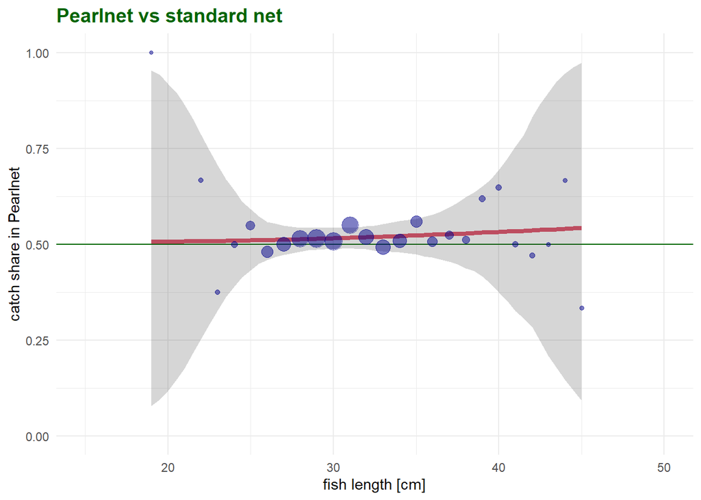

```r
p_cc_ple<-ggplot(data=mod_ple[["ccl.ci"]],aes(x=l))+
  coord_cartesian(xlim=c(15,50),ylim=c(0,1))+
  geom_hline(yintercept = 0.5,col="darkgreen")+
  geom_line( aes(y=mu),col=2,lwd=1.5) + xlab("fish length [cm]") +ylab("catch share in Pearlnet")+
  geom_ribbon(aes(ymin=lci, ymax=uci), alpha=0.2)+
  geom_point(data=mod_ple[["dt_out"]],aes(x=l,y=p_l,size=n_l), alpha=.5,col="darkblue")+
  ggtitle("Pearlnet vs standard net")+
  theme_minimal()+
  theme(plot.title = element_text(color="darkgreen", size=14, face="bold"), legend.position="none")

print(p_cc_ple)
```

To plot the catch ratio curve derived from the comparison curve only the object `crl.ci` stored in the model object `mod_ple` needs to be used:

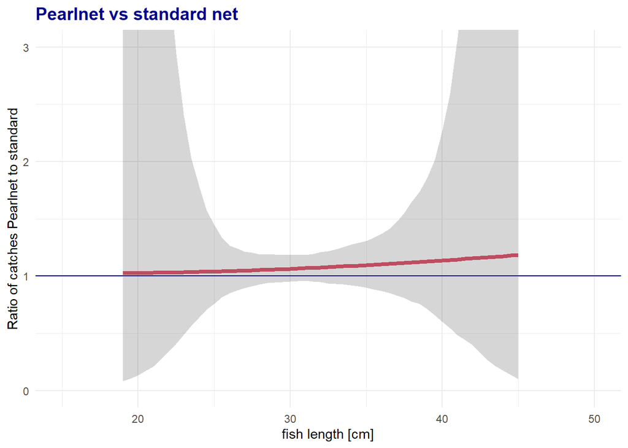

```r
p_cr_ple<-ggplot(data=mod_ple[["crl.ci"]],aes(x=l))+
  coord_cartesian(xlim=c(15,50),ylim=c(0,3))+
  geom_hline(yintercept = 1,col="darkblue")+
  geom_line( aes(y=mu),col=2,lwd=1.5) + xlab("fish length [cm]")  +ylab("Ratio of catches Pearlnet to standard")+
  geom_ribbon(aes(ymin=lci, ymax=uci), alpha=0.2)+
  ggtitle("Pearlnet vs standard net")+
    theme_minimal()+
  theme(plot.title = element_text(color="darkblue", size=14, face="bold"), legend.position="none")

print(p_cr_ple)
```